# zg21696_EMATM0061_A_Report

Ruinan Wang

20/12/2021

### A.1

#### Begin by downloading the csv file available within the Assessment section within Blackboard entitled “finance_data_EMATM0061”. Next load the “finance_data_EMATM0061” csv file into R data frame called “finance_data_original”.

```r
data = read.csv("finance_data_EMATM0061.csv", header = TRUE)
```

#### How many rows and how many columns does this data frame have?

there are 1051 rows and 30 columns.

```r
dim(data)
```

```
## [1] 1051   30
```

### A.2

#### Generate a new data frame called “finance_data” which is a subset of the “finance_data_original” data frame with the same number of rows, but only six columns:

- The first column should be called “state_year_code” and correspond to the “state_year_code” column in the csv.
- The second column should be called “education_expenditure” and should correspond to the “Details.Education.Education.Total” column in the csv.
- The third column should be called “health_expenditure” and should correspond to the “Details.Health.Health.Total.Expenditure” column in the csv.
- The fourth column should be called “transport_expenditure” and should correspond to the “Details.Transportation.Highways.Highways.Total.Expenditure” column in the csv.
- The fifth column should be called “totals_revenue” and should correspond to the “Totals.Revenue” column in the csv.
- The sixth column should be called “totals_expenditure” and should correspond to the “Totals.Expenditure” column in the csv.

```r
library(tidyverse)
finance_data <- data %>% select(state_year_code,
                                education_expenditure = Details.Education.Education.Total,
                                health_expenditure = Details.Health.Health.Total.Expenditure,
                                transport_expenditure = Details.Transportation.Highways.Highways.Total.Expenditure,
                                totals_revenue = Totals.Revenue,
                                totals_expenditure = Totals.Expenditure)

dim(finance_data)
```

```
## [1] 1051    6
```

#### Display a subset of the “finance_data” dataframe consisting of the first five rows and first three columns (“state_year_code”,“education_expenditure”,“health_expenditure”)

```r
head(finance_data%>%select(state_year_code,education_expenditure,health_expenditure),5)
```

```
##   state_year_code education_expenditure health_expenditure
## 1   ALABAMA__1992               3570524                 NA
## 2   ALABAMA__1993               3663465                 NA
## 3   ALABAMA__1994               3969277             487044
## 4   ALABAMA__1995               4400912             491648
## 5   ALABAMA__1996               4872259             514380
```

### A.3

#### Create a new column within the “finance_data” data frame called “totals_savings” which is equal to the difference between revenue and the expenditure ie. the elements of the “totals_savings” column are equal to elements within the “totals_revenue” minus the element within the “totals_expenditure” column, for each row. And the “finance_data” data frame should now have seven columns.

```r
finance_data <- finance_data %>% mutate(totals_savings = totals_revenue - totals_expenditure)
dim(finance_data)
```

```
## [1] 1051    7
```

#### Display a subset of the “finance_data” dataframe consisting of the first three rows and the four columns “state_year_code”,“totals_revenue”, “totals_expenditure”, “totals_savings”

```r
head(finance_data%>%select(state_year_code,totals_revenue,totals_expenditure,totals_savings),3)
```

```
##   state_year_code totals_revenue totals_expenditure totals_savings
## 1   ALABAMA__1992       10536166            9650515         885651
## 2   ALABAMA__1993       11389335           10242374        1146961
## 3   ALABAMA__1994       11599362           10815221         784141
```

### A.4

#### The “state_year_code” column within your “finance_data” data frame contains both a state and a year in character format connected via a double underscore. Divide the “state_year_code” column into two separate columns, a “state” column and a “year” column which replace the original “state_year_code” column. The “finance_data” data frame should now have 1051 rows and 8 columns

```r
finance_data <- finance_data %>% separate(col = "state_year_code",into = c("state","year"), sep = "__", convert = TRUE)
dim(finance_data)
```

```
## [1] 1051    8
```

#### Convert the states so that they appear with the first letter of each word in upper case and the remainder in lower case eg. we should see “New Hampshire” rather than “NEW HAMPSHIRE”. You may wish to use the function str_to_title(). Display a subset of the “finance_data” data frame consisting of the first three rows and the five columns “state”, “year”, “totals_revenue”, “totals_expenditure”, “totals_savings”

```r
finance_data <- finance_data %>% mutate(state = str_to_title(state))
head(finance_data%>%select(state, year, totals_revenue, totals_expenditure, totals_savings),3)
```

```
##     state year totals_revenue totals_expenditure totals_savings
## 1 Alabama 1992       10536166            9650515         885651
## 2 Alabama 1993       11389335           10242374        1146961
## 3 Alabama 1994       11599362           10815221         784141
```

### A.5

#### Generate a plot which displays the total revenue (“total_revenue”) as function of the year (“year”) for the following four states: Louisiana, Montana, Mississippi and Kentucky. Display the revenue in terms of millions of dollars.

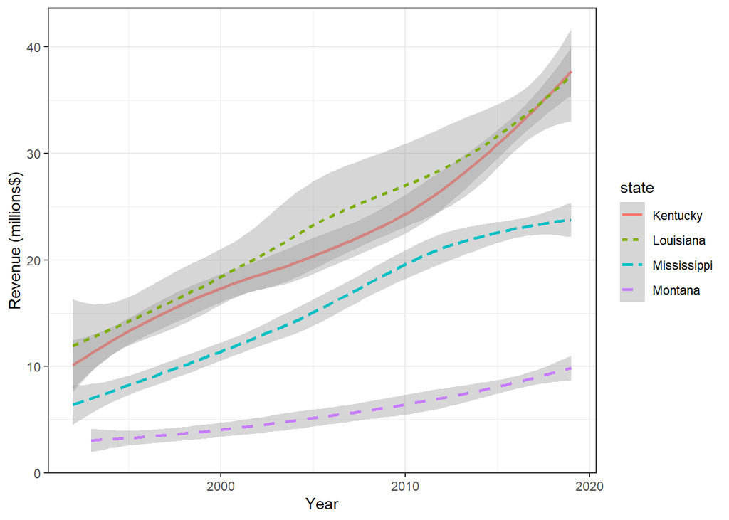

```r
## First, extract the target data and change the unit of "totals_revenue"
four_states_revenue_by_year <- finance_data %>%
  filter(state %in% c("Louisiana", "Montana", "Mississippi", "Kentucky"))%>%
  mutate(totals_revenue_in_mill = totals_revenue/1000000)%>%
  select(state,year,totals_revenue_in_mill)
## Plot the revenue changes of the four states over time
ggplot(four_states_revenue_by_year, aes(x=year, y=totals_revenue_in_mill, color=state, linetype=state))+labs(x="Year", y="Revenue (millions$)")+geom_smooth(method="loess", formula = 'y ~ x')+ theme_bw()
```

### A.6

#### Create a function called get_decade() which takes as input a number and rounds that number down to the nearest multiple of 10. For example, the numbers 20,21,22,…,29 would all be mapped to the output 20

```r
get_decade <- function(val){
  temp <- floor(val/10)
  decade<- temp *10
  return(decade)
}
```

#### Use your get_decade() function to add a new column to the “finance_data” data frame called “decade” which should give the decade corresponding to the year column. For example, the decade of the years 1990,1991,. . . ,1998,1999 is 1990. Your “finance_data” data frame should now have nine columns.

```r
finance_data <- finance_data%>%mutate(decade = get_decade(year))
dim(finance_data)
```

```
## [1] 1051    9
```

#### Which three states had the highest mean-average savings (“totals_savings”) over the decade starting 2000?

It can be seen from the table below that Texas, Ohio, California are the three states which had the highest mean-average savings in the decade from 2000 to 2010.

```r
head(finance_data %>%
       filter(decade == 2000)%>%
       group_by(state)%>%
       summarise(mean_average_savings= mean(totals_savings, na.rm=TRUE))%>%
       arrange(desc(mean_average_savings)), 3)
```

```
## # A tibble: 3 x 2
##   state      mean_average_savings
##   <chr>                     <dbl>
## 1 Texas                  4103352.
## 2 Ohio                   3025980
## 3 California             2510483.
```

### A.7

#### Next generate a summary data frame from the “inance_data” data frame called “alaska_summary” with the following properties:

#### Your summary data frame should correspond to rows associated with the state of Alaska. Your summary data frame should have three rows each corresponding to a decade from 1990 through to 2010 inclusive. Your data frame should also have seven columns:

- 1. “decade” – the decade (1990, 2000, 2010)
- 2. “ed_mn” – the mean of the education expenditure in Alaska for the corresponding decade
- 3. “ed_md” – the median of the education expenditure in Alaska for the corresponding decade
- 4. “he_mn” – the mean of the health expenditure in Alaska for the corresponding decade
- 5. “he_md” – the median of the health expenditure in Alaska for the corresponding decade
- 6. “tr_mn” – the mean of the transport expenditure in Alaska for the corresponding decade
- 7. “tr_md” – the median of the transport expenditure in Alaska for the corresponding decade